# Desarrollo de distintas enfermedades según el oficio

Fuentes de datos biomédicas y web semántica, Grado en Ingeniería de la Salud

Lorena Nerín Grau y Lucía González Redondo

2024-11-18

# **Introducción**

El desarrollo de enfermedades laborales pueden ocasionar bajas laborales. Estás enfermedades se producen en el ámbito laboral según el trabajo realizado, pero queremos estudiar como el desarrollo de estas enfermedades se puede agravar por poseer una enfermedad mental, incluso si la gravedad de la enfermedad laboral es distinta entre géneros o debido a la profesión realizada.

# **Objetivo general**

Evaluación del desarrollo de enfermedades laborales, respecto a la profesión y el estado de salud mental.

# **Objetivo específico**

- ¿Existe relación la profesión de movimiento de tierra respecto al desarrollo de enfermedades psicológicas?
- ¿Existe relación entre el desarrollo de enfermedades laborales respecto al sexo?
- ¿Exsite relación entre la gravedad de una enfermedad psicológica respecto al desarrollo de una enfermedad laboral?

# **Metodología**

## **Materiales**

Agregamos los URL del lugar de obtención de los datos:

- Enfermedades laborales
- Estado de salud mental
- [Tipos de trabajos](https://datos.gob.es/es/catalogo/a05003423-accidentes-de-trabajo-en-jornada-segun-tipos-de-trabajo-gravedad-trabajo-habitual-o-no-y-sexos-canarias-y-anos)
- [Grado de lesión de la enfermedad laboral](https://datos.gob.es/es/catalogo/a02002834-accidentes-en-jornada-de-trabajo-n-de-accidentes-segun-grado-de-lesion-y-sexo)

Agregamos el URL del repositorio: - [Repositorio](https://github.com/Lucia-G-R/Seminario_Fuentes.git)

### **Carga de paquetes**

Paquetes necesarios para JSON

```r
# Paquetes necesarios para JSON
#install.packages("tidyjson")
```

Paquetes necesarios para xls

```r
# Paquetes necesarios para xls
#install.packages("readxl")
```

Paquetes necesarios para csv

```r
# Paquetes necesarios para csv
#install.packages("readr")
```

Paquetes necesarios para xlsx

```r
# Paquetes necesarios para xlsx
#install.packages("readxl")
```

Paquete necesario para la manipulación de dataframes

```r
# Paquete necesario para la manipulación de dataframes
#install.packages("dplyr")
```

Paquete necesario para transformar las filas y columnas

```r
# Paquete necesario para transformar las filas y columnas
#install.packages("tidyverse")
```

Paquete para mostrar las tablas formatedas

```r
#Paquete para mostrar tablas formatedas
#install.packages("DT")
```

## **Carga de datos**

### **Descargar datos**

Podemos descargar los datos de Canarias en formato .csv de la página web de datos del gobierno de España, desde R mediante este código:

```r
#install.packages("readxl")
library(readxl)

# URL del archivo Excel en GitHub
url <- "https://github.com/Lucia-G-R/Seminario_Fuentes/blob/main/INPUT/DATA/Enfermedades_laborales_Espa%C3%B1a.csv.csv"

# Creamos un archivo temporal para almacenar el Excel
temp <- tempfile(fileext = ".csv")

# Descargamos el archivo desde GitHub
download.file("https://datos.gob.es/es/catalogo/a05003423-poblacion-de-16-y-mas-anos-segun-autovaloracion-del-estado-de-salud-en-relacion-a-situaciones-de-ansiedad-o-depresion-sexos-o-grupos-de-edad-por-anos-canarias-2004-2009", destfile = temp, mode = "wb")
```

### **Carga de datos JSON**

Queremos extraer los datos sobre las enfermedades laborales que suceden en España. Como es un archivo con extensión .JSON con listas anidadas sin etiquetar, no podemos utilizar directamente un tibbe para ello, utilizaremos tidyjson.

```r
library(rjson)
library(tidyverse)
library(tidyjson)
library(dplyr)
library(DT)

# Cargamos el archivo JSON, pero está en formato de lista.
espana_json <- fromJSON(file = "INPUT/DATA/Enfermedades_laborales_España.json")

# Observamos la estructura, nos damos cuenta que posee listas anidadas
#str(espana_json)

# Convertimos la lista de la varable MetaData en un dataframe
MetaData_df<-
  espana_json%>%
  enter_object("MetaData")%>% # Extreamos la infromación dentro de "MetaData"
  gather_array() %>% # Convierte los elementos de un array en filas
  spread_all()%>% # Esta función distribuye cualquier objeto JSON que sea escalar en nuevas columnas
  select(T3_Variable, Nombre, Codigo) # Seleccionamos las tres variables que posee

# Convertimos la lista de la variable Data en un dataframe
Data_df<-
  espana_json%>%
  enter_object("Data")%>% # Extreamos la infromación dentro de "Data"
  gather_array() %>%
  spread_all()%>%
  select(Valor) # Seleccionamos la variable que posee

# Unimos MetaData_df y Data_df usando "..JSON". Extraemos la columna "..JSON" como identificador
# Expandimos la columna "..JSON" con prefijo para evitar conflictos de nombres
MetaData_df <-
  MetaData_df %>%
  unnest_wider(..JSON, names_sep = "_json")

Data_df <-
  Data_df %>%
  unnest_wider(..JSON, names_sep = "_json")

# Creamos un identificador único para cada fila
MetaData_df <-
  MetaData_df %>%
  mutate(id = row_number())

Data_df <-
  Data_df %>%
  mutate(id = row_number())

# Hacemos la unión de los df por la columna id que hemos creado con la variable lista "..JSON"
espana_df <-
  MetaData_df %>%
  left_join(Data_df, by = "id") %>% # Unimos con Data_df usando 'id'
  mutate(Nombre = espana_json$Nombre) # Agregamos la columna "Nombre" del espana_json

#attributes(MetaData_df)
#attributes(Data_df)
#print(MetaData_df)
#print(Data_df)
#print(espana_json)
#print(espana_df)


datatable(espana_df)
```

|  | T3_Variable | Codigo | ..JSON_jsonT3_Variable | ..JSON_jsonNombre | ..JSON_jsonCodigo | id | Valor | ..JSON_jsonValor |
| --- | --- | --- | --- | --- | --- | --- | --- | --- |
| 1 | tipo de enfermedad | total | tipo de enfermedad | Total | total | 1 | 2000.9 | 2000.9 |
| 2 | tipo de indicador | valoresabsolutosenmiles | tipo de indicador | Valores absolutos en miles | valoresabsolutosenmiles | 2 | 948.6 | 948.6 |
| 3 | sexo | ambossexos | sexo | Ambos sexos | ambossexos | 3 | 1052.3 | 1052.3 |
| 4 | tipo de enfermedad | total | tipo de enfermedad | Total | total | 4 | 100 | 100 |
| 5 | tipo de indicador | valoresabsolutosenmiles | tipo de indicador | Valores absolutos en miles | valoresabsolutosenmiles | 5 | 100 | 100 |
| 6 | sexo | hombres | sexo | Hombres | hombres | 6 | 100 | 100 |
| 7 | tipo de enfermedad | total | tipo de enfermedad | Total | total | 7 | 398.4 | 398.4 |
| 8 | tipo de indicador | valoresabsolutosenmiles | tipo de indicador | Valores absolutos en miles | valoresabsolutosenmiles | 8 | 144 | 144 |
| 9 | sexo | mujeres | sexo | Mujeres | mujeres | 9 | 254.3 | 254.3 |
| 10 | tipo de enfermedad | total | tipo de enfermedad | Total | total | 10 | 19.91 | 19.91 |

[output cut: 242 more lines]

### **Carga de datos XLS**

Queremos extraer los datos sobre los accidentes laborales que suceden en Canarias. Como es un archivo con extensión .xls, utilizamos read_excel.

```r
# Cargamos los archivos con extensión .xls
library(readxl)
library(DT)

canarias_df <- read_excel("INPUT/DATA/Accidentes_laborales_Canarias.xls")
#class(canarias_df)

#print(canarias_df)
datatable(canarias_df)
```

|  | TIME_PERIOD#es | TIME_PERIOD_CODE | SEXO#es | SEXO_CODE | ACCIDENTE_GRAVEDAD#es | ACCIDENTE_GRAVEDAD_CODE | TIPO_TRABAJO#es | TIPO_TRABAJO_CODE | TRABAJO_HABITUAL#es | TRABAJO_HABITUAL_CODE | OBS_VALUE | CONFIDENCIALIDAD_OBSERVACION#es | NOTAS_OBSERVACION#es | ESTADO_OBSERVACION#es |
| --- | --- | --- | --- | --- | --- | --- | --- | --- | --- | --- | --- | --- | --- | --- |
| 1 | 2003 | 2003 | Mujeres | F | Total | _T | Labores movimiento tierras, construcción, mantenimiento, demolición | 2 | Sí | SI | 175 |  |  |  |
| 2 | 2003 | 2003 | Hombres | M | Total | _T | Labores movimiento tierras, construcción, mantenimiento, demolición | 2 | Sí | SI | 10115 |  |  |  |
| 3 | 2003 | 2003 | Total | _T | Total | _T | Labores movimiento tierras, construcción, mantenimiento, demolición | 2 | Sí | SI | 10290 |  |  |  |
| 4 | 2004 | 2004 | Mujeres | F | Total | _T | Labores movimiento tierras, construcción, mantenimiento, demolición | 2 | Sí | SI | 81 |  |  |  |
| 5 | 2004 | 2004 | Hombres | M | Total | _T | Labores movimiento tierras, construcción, mantenimiento, demolición | 2 | Sí | SI | 9060 |  |  |  |
| 6 | 2004 | 2004 | Total | _T | Total | _T | Labores movimiento tierras, construcción, mantenimiento, demolición | 2 | Sí | SI | 9141 |  |  |  |
| 7 | 2005 | 2005 | Mujeres | F | Total | _T | Labores movimiento tierras, construcción, mantenimiento, demolición | 2 | Sí | SI | 83 |  |  |  |
| 8 | 2005 | 2005 | Hombres | M | Total | _T | Labores movimiento tierras, construcción, mantenimiento, demolición | 2 | Sí | SI | 9089 |  |  |  |
| 9 | 2005 | 2005 | Total | _T | Total | _T | Labores movimiento tierras, construcción, mantenimiento, demolición | 2 | Sí | SI | 9172 |  |  |  |
| 10 | 2006 | 2006 | Mujeres | F | Total | _T | Labores movimiento tierras, construcción, mantenimiento, demolición | 2 | Sí | SI | 85 |  |  |  |

[output cut: 6470 more lines]

### **Carga de datos CSV**

Queremos extraer los datos sobre la salud mental en los habitantes de Canarias. Como es un archivo con extensión .csv, utilizamos read_delim e indicamos que el delimitador es ; Al imprimirlo como tabla con la función datatable nos da un error con el formato, es decir, indica que hay un problema con la codificación del archivo CSV. En este caso, el error nos indica que los archivos están codificados en UTF-8, pero revisando la tabla incluye caracteres como acentos. Por eso, utilizamos locale que es una forma de configurar la codificación de caracteres que define cómo se representan los caracteres de texto en bytes. En conclusión con encoding = “ISO-8859-1” queremos que R interprete el archivo usando la codificación Latin-1, esta configuración asegura que los caracteres especiales se lean e interpreten de forma adecuada, evitando caracteres raros.

```r
# Cargamos los archivos con extensión .csv
library(readr)
library(DT)

Salud_df <- read_delim ("INPUT/DATA/Estados_de_salud_Canarias.csv.csv", delim = ";", locale = locale(encoding = "ISO-8859-1"))
#class(Salud_df)

datatable(Salud_df)
```

|  | sexos_grupos_edad | indicadores | autovaloracion_estado_salud_relacion_situaciones_ansiedad | anios | poblacion_16_mas_anios |
| --- | --- | --- | --- | --- | --- |
| 1 | Ambos sexos | Absoluto | Total | 2009 | 1784860 |
| 2 | Ambos sexos | Absoluto | Total | 2004 | 1616594 |
| 3 | Ambos sexos | Absoluto | No está ansioso ni deprimido | 2009 | 1394989 |
| 4 | Ambos sexos | Absoluto | No está ansioso ni deprimido | 2004 | 1202715 |
| 5 | Ambos sexos | Absoluto | Está moderadamente ansioso o deprimido | 2009 | 315192 |
| 6 | Ambos sexos | Absoluto | Está moderadamente ansioso o deprimido | 2004 | 330939 |
| 7 | Ambos sexos | Absoluto | Está muy ansioso o deprimido | 2009 | 70990 |
| 8 | Ambos sexos | Absoluto | Está muy ansioso o deprimido | 2004 | 75083 |
| 9 | Ambos sexos | Absoluto | No sabe/No contesta | 2009 | 3689 |
| 10 | Ambos sexos | Absoluto | No sabe/No contesta | 2004 | 7858 |

[output cut: 90 more lines]

### **Carga de datos XLSX**

Queremos extraer los datos sobre la gravedad de las enfermedades laborales producidas en Aragón. Como es un archivo con extensión .xlsx, utilizamos read_excel.

```r
# Cargamos los archivos con extensión .xlsx
library(readxl)
library(DT)

Aragon_df <- read_excel ("INPUT/DATA/070901-02_Por grado y sexo. Aragon.xlsx")
#class(Aragon_df)

print(Aragon_df)
```

```
## # A tibble: 121 × 6
##      Año Sexo    `Nº Accidentes` `Grupo Grado Código...4` Grupo Grado Código..…¹
##    <dbl> <chr>             <dbl> <chr>                                     <dbl>
##  1  2023 Hombres           12082 Leves                                         1
##  2  2023 Mujeres            4784 Leves                                         1
##  3  2022 Hombres           11954 Leves                                         1
##  4  2022 Mujeres            5073 Leves                                         1
##  5  2021 Hombres           11559 Leves                                         1
##  6  2021 Mujeres            4739 Leves                                         1
##  7  2020 Hombres           10651 Leves                                         1
##  8  2020 Mujeres            4727 Leves                                         1
##  9  2019 Hombres           11909 Leves                                         1
## 10  2019 Mujeres            4511 Leves                                         1
## # ℹ 111 more rows
## # ℹ abbreviated name: ¹`Grupo Grado Código...5`
## # ℹ 1 more variable: CCAA <chr>
```

```r
datatable(Aragon_df)
```

|  | Año | Sexo | Nº Accidentes | Grupo Grado Código...4 | Grupo Grado Código...5 | CCAA |
| --- | --- | --- | --- | --- | --- | --- |
| 1 | 2023 | Hombres | 12082 | Leves | 1 | Aragón |
| 2 | 2023 | Mujeres | 4784 | Leves | 1 | Aragón |
| 3 | 2022 | Hombres | 11954 | Leves | 1 | Aragón |
| 4 | 2022 | Mujeres | 5073 | Leves | 1 | Aragón |
| 5 | 2021 | Hombres | 11559 | Leves | 1 | Aragón |
| 6 | 2021 | Mujeres | 4739 | Leves | 1 | Aragón |
| 7 | 2020 | Hombres | 10651 | Leves | 1 | Aragón |
| 8 | 2020 | Mujeres | 4727 | Leves | 1 | Aragón |
| 9 | 2019 | Hombres | 11909 | Leves | 1 | Aragón |
| 10 | 2019 | Mujeres | 4511 | Leves | 1 | Aragón |

[output cut: 111 more lines]

## **Observar valores nulos**

Observamos los valores nulos del conjunto de datos sobre los accidentes laborales que suceden en Canarias. Con select observamos las columnas que poseen valores nulos..

```r
library(dplyr)

canarias_df %>%
select(where(~ all(is.na(.))))
```

```
## # A tibble: 6,480 × 3
##    CONFIDENCIALIDAD_OBSERVACION#…¹ `NOTAS_OBSERVACION#es` ESTADO_OBSERVACION#e…²
##    <lgl>                           <lgl>                  <lgl>
##  1 NA                              NA                     NA
##  2 NA                              NA                     NA
##  3 NA                              NA                     NA
##  4 NA                              NA                     NA
##  5 NA                              NA                     NA
##  6 NA                              NA                     NA
##  7 NA                              NA                     NA
##  8 NA                              NA                     NA
##  9 NA                              NA                     NA
## 10 NA                              NA                     NA
## # ℹ 6,470 more rows
## # ℹ abbreviated names: ¹`CONFIDENCIALIDAD_OBSERVACION#es`,
## #   ²`ESTADO_OBSERVACION#es`
```

## **Cambiar nombre de las columnas**

Vamos a cambiar los nombres de las distintas columnas de los datos extraídos. Cambiamos los nombres de las columnas del conjunto de datos sobre los accidentes laborales que suceden en Canarias.

```r
library(tidyverse)
library(DT)

#attributes(canarias_df)
canarias <- rename(.data = canarias_df, Año = `TIME_PERIOD#es`, Año2 = `TIME_PERIOD_CODE`, Sexo = `SEXO#es`, SexoCod = `SEXO_CODE`, Gravedad = `ACCIDENTE_GRAVEDAD#es`, GravedadCod = `ACCIDENTE_GRAVEDAD_CODE`, TipoTrab = `TIPO_TRABAJO#es`, TipoTrabCod = `TIPO_TRABAJO_CODE`, TrabHabitual = `TRABAJO_HABITUAL#es`, TrabHabCod = `TRABAJO_HABITUAL_CODE`, Obs = `OBS_VALUE`, ConfeciObs = `CONFIDENCIALIDAD_OBSERVACION#es`, Notasobs = `NOTAS_OBSERVACION#es`, Estadosobs = `ESTADO_OBSERVACION#es`)

datatable(canarias)
```

|  | Año | Año2 | Sexo | SexoCod | Gravedad | GravedadCod | TipoTrab | TipoTrabCod | TrabHabitual | TrabHabCod | Obs | ConfeciObs | Notasobs | Estadosobs |
| --- | --- | --- | --- | --- | --- | --- | --- | --- | --- | --- | --- | --- | --- | --- |
| 1 | 2003 | 2003 | Mujeres | F | Total | _T | Labores movimiento tierras, construcción, mantenimiento, demolición | 2 | Sí | SI | 175 |  |  |  |
| 2 | 2003 | 2003 | Hombres | M | Total | _T | Labores movimiento tierras, construcción, mantenimiento, demolición | 2 | Sí | SI | 10115 |  |  |  |
| 3 | 2003 | 2003 | Total | _T | Total | _T | Labores movimiento tierras, construcción, mantenimiento, demolición | 2 | Sí | SI | 10290 |  |  |  |
| 4 | 2004 | 2004 | Mujeres | F | Total | _T | Labores movimiento tierras, construcción, mantenimiento, demolición | 2 | Sí | SI | 81 |  |  |  |
| 5 | 2004 | 2004 | Hombres | M | Total | _T | Labores movimiento tierras, construcción, mantenimiento, demolición | 2 | Sí | SI | 9060 |  |  |  |
| 6 | 2004 | 2004 | Total | _T | Total | _T | Labores movimiento tierras, construcción, mantenimiento, demolición | 2 | Sí | SI | 9141 |  |  |  |
| 7 | 2005 | 2005 | Mujeres | F | Total | _T | Labores movimiento tierras, construcción, mantenimiento, demolición | 2 | Sí | SI | 83 |  |  |  |
| 8 | 2005 | 2005 | Hombres | M | Total | _T | Labores movimiento tierras, construcción, mantenimiento, demolición | 2 | Sí | SI | 9089 |  |  |  |
| 9 | 2005 | 2005 | Total | _T | Total | _T | Labores movimiento tierras, construcción, mantenimiento, demolición | 2 | Sí | SI | 9172 |  |  |  |
| 10 | 2006 | 2006 | Mujeres | F | Total | _T | Labores movimiento tierras, construcción, mantenimiento, demolición | 2 | Sí | SI | 85 |  |  |  |

[output cut: 6470 more lines]

Cambiamos los nombres de las columnas del conjunto de datos sobre la gravedad de las enfermedades laborales producidas en Aragón.

```r
library(tidyverse)
library(DT)

#attributes(Aragon_df)
Aragon <- rename(.data = Aragon_df, NumAcci = `Nº Accidentes`, Gravedad = `Grupo Grado Código...4`, GravedadCod = `Grupo Grado Código...5`)

#print(Aragon)
datatable(Aragon)
```

|  | Año | Sexo | NumAcci | Gravedad | GravedadCod | CCAA |
| --- | --- | --- | --- | --- | --- | --- |
| 1 | 2023 | Hombres | 12082 | Leves | 1 | Aragón |
| 2 | 2023 | Mujeres | 4784 | Leves | 1 | Aragón |
| 3 | 2022 | Hombres | 11954 | Leves | 1 | Aragón |
| 4 | 2022 | Mujeres | 5073 | Leves | 1 | Aragón |
| 5 | 2021 | Hombres | 11559 | Leves | 1 | Aragón |
| 6 | 2021 | Mujeres | 4739 | Leves | 1 | Aragón |
| 7 | 2020 | Hombres | 10651 | Leves | 1 | Aragón |
| 8 | 2020 | Mujeres | 4727 | Leves | 1 | Aragón |
| 9 | 2019 | Hombres | 11909 | Leves | 1 | Aragón |
| 10 | 2019 | Mujeres | 4511 | Leves | 1 | Aragón |

[output cut: 111 more lines]

Cambiamos los nombres de las columnas del conjunto de datos sobre las enfermedades laborales que suceden en España.

```r
library(tidyverse)
library(DT)

#attributes(espana_df)
Espana <- rename(.data = espana_df, TipoEnf = `T3_Variable`, Indicador = `Codigo`, Variable = `..JSON_jsonT3_Variable`, Nombre = `..JSON_jsonNombre`, Codigo = `..JSON_jsonCodigo`, jsonValor = `..JSON_jsonValor`)

#print(Espana)
datatable(Espana)
```

|  | TipoEnf | Indicador | Variable | Nombre | Codigo | id | Valor | jsonValor |
| --- | --- | --- | --- | --- | --- | --- | --- | --- |
| 1 | tipo de enfermedad | total | tipo de enfermedad | Total | total | 1 | 2000.9 | 2000.9 |
| 2 | tipo de indicador | valoresabsolutosenmiles | tipo de indicador | Valores absolutos en miles | valoresabsolutosenmiles | 2 | 948.6 | 948.6 |
| 3 | sexo | ambossexos | sexo | Ambos sexos | ambossexos | 3 | 1052.3 | 1052.3 |
| 4 | tipo de enfermedad | total | tipo de enfermedad | Total | total | 4 | 100 | 100 |
| 5 | tipo de indicador | valoresabsolutosenmiles | tipo de indicador | Valores absolutos en miles | valoresabsolutosenmiles | 5 | 100 | 100 |
| 6 | sexo | hombres | sexo | Hombres | hombres | 6 | 100 | 100 |
| 7 | tipo de enfermedad | total | tipo de enfermedad | Total | total | 7 | 398.4 | 398.4 |
| 8 | tipo de indicador | valoresabsolutosenmiles | tipo de indicador | Valores absolutos en miles | valoresabsolutosenmiles | 8 | 144 | 144 |
| 9 | sexo | mujeres | sexo | Mujeres | mujeres | 9 | 254.3 | 254.3 |
| 10 | tipo de enfermedad | total | tipo de enfermedad | Total | total | 10 | 19.91 | 19.91 |

[output cut: 242 more lines]

Cambiamos los nombres de las columnas del conjunto de datos sobre la salud mental en los habitantes de Canarias.

```r
library(tidyverse)
library(DT)

#attributes(Salud_df)
Salud <- rename(.data = Salud_df, Sexo = `sexos_grupos_edad`, EstadoAnsiedad = `autovaloracion_estado_salud_relacion_situaciones_ansiedad`, Años = `anios`, Obs = `poblacion_16_mas_anios`)

#print(Salud)
datatable(Salud)
```

|  | Sexo | indicadores | EstadoAnsiedad | Años | Obs |
| --- | --- | --- | --- | --- | --- |
| 1 | Ambos sexos | Absoluto | Total | 2009 | 1784860 |
| 2 | Ambos sexos | Absoluto | Total | 2004 | 1616594 |
| 3 | Ambos sexos | Absoluto | No está ansioso ni deprimido | 2009 | 1394989 |
| 4 | Ambos sexos | Absoluto | No está ansioso ni deprimido | 2004 | 1202715 |
| 5 | Ambos sexos | Absoluto | Está moderadamente ansioso o deprimido | 2009 | 315192 |
| 6 | Ambos sexos | Absoluto | Está moderadamente ansioso o deprimido | 2004 | 330939 |
| 7 | Ambos sexos | Absoluto | Está muy ansioso o deprimido | 2009 | 70990 |
| 8 | Ambos sexos | Absoluto | Está muy ansioso o deprimido | 2004 | 75083 |
| 9 | Ambos sexos | Absoluto | No sabe/No contesta | 2009 | 3689 |
| 10 | Ambos sexos | Absoluto | No sabe/No contesta | 2004 | 7858 |

[output cut: 90 more lines]

## **Eliminar columnas**

Eliminamos las columnas que no nos va a interesar estudiar para ello, seleccionamos las columnas que nos interesan. En el único conjunto de datos que no vamos a eliminar columnas es en los datos sobre la salud mental en los habitantes de Canarias. Primero vamos a eliminar las columnas del conjunto de datos de canarias. Nos vamos a quedar solo con las columnas Año, Sexo, Gravedad, TipoTrab y Obs.

```r
library(dplyr)

canarias <-
  canarias%>%
  select(Año, Sexo, Gravedad, TipoTrab, Obs)
datatable(canarias)
```

|  | Año | Sexo | Gravedad | TipoTrab | Obs |
| --- | --- | --- | --- | --- | --- |
| 1 | 2003 | Mujeres | Total | Labores movimiento tierras, construcción, mantenimiento, demolición | 175 |
| 2 | 2003 | Hombres | Total | Labores movimiento tierras, construcción, mantenimiento, demolición | 10115 |
| 3 | 2003 | Total | Total | Labores movimiento tierras, construcción, mantenimiento, demolición | 10290 |
| 4 | 2004 | Mujeres | Total | Labores movimiento tierras, construcción, mantenimiento, demolición | 81 |
| 5 | 2004 | Hombres | Total | Labores movimiento tierras, construcción, mantenimiento, demolición | 9060 |
| 6 | 2004 | Total | Total | Labores movimiento tierras, construcción, mantenimiento, demolición | 9141 |
| 7 | 2005 | Mujeres | Total | Labores movimiento tierras, construcción, mantenimiento, demolición | 83 |
| 8 | 2005 | Hombres | Total | Labores movimiento tierras, construcción, mantenimiento, demolición | 9089 |
| 9 | 2005 | Total | Total | Labores movimiento tierras, construcción, mantenimiento, demolición | 9172 |
| 10 | 2006 | Mujeres | Total | Labores movimiento tierras, construcción, mantenimiento, demolición | 85 |

[output cut: 6470 more lines]

En segundo lugar, eiminamos las columnas del conjunto de datos de Aragon. Nos vamos a quedar solo con las columnas Año, Sexo, NumAcci y Gravedad.

```r
library(dplyr)

Aragon <-
  Aragon%>%
  select(Año, Sexo, NumAcci, Gravedad)
datatable(Aragon)
```

|  | Año | Sexo | NumAcci | Gravedad |
| --- | --- | --- | --- | --- |
| 1 | 2023 | Hombres | 12082 | Leves |
| 2 | 2023 | Mujeres | 4784 | Leves |
| 3 | 2022 | Hombres | 11954 | Leves |
| 4 | 2022 | Mujeres | 5073 | Leves |
| 5 | 2021 | Hombres | 11559 | Leves |
| 6 | 2021 | Mujeres | 4739 | Leves |
| 7 | 2020 | Hombres | 10651 | Leves |
| 8 | 2020 | Mujeres | 4727 | Leves |
| 9 | 2019 | Hombres | 11909 | Leves |
| 10 | 2019 | Mujeres | 4511 | Leves |

[output cut: 111 more lines]

En tercer lugar, eiminamos las columnas del conjunto de datos de Espana. Nos vamos a quedar solo con las columnas Nombre, id y Valor.

```r
library(dplyr)

Espana <-
  Espana%>%
  select(Nombre, id, Valor)
datatable(Espana)
```

|  | Nombre | id | Valor |
| --- | --- | --- | --- |
| 1 | Total | 1 | 2000.9 |
| 2 | Valores absolutos en miles | 2 | 948.6 |
| 3 | Ambos sexos | 3 | 1052.3 |
| 4 | Total | 4 | 100 |
| 5 | Valores absolutos en miles | 5 | 100 |
| 6 | Hombres | 6 | 100 |
| 7 | Total | 7 | 398.4 |
| 8 | Valores absolutos en miles | 8 | 144 |
| 9 | Mujeres | 9 | 254.3 |
| 10 | Total | 10 | 19.91 |

[output cut: 242 more lines]

## **Eliminar filas**

Eliminamos las filas que no nos va a interesar estudiar.

```r
#ELIMINAR FILAS

Salud <- subset(Salud, !Sexo %in% c("De 16 a 64 a\xf1os", "De 65 y m\xe1s a\xf1os"))

#canarias <- subset(canarias, !TipoTrabCod %in% c("4|9|_T|3|6|0|5|1"))

Espana <- subset (Espana, !TipoEnf %in% c ("Cardiopartía|Dolor de cabeza|infecciosa|No sabe|problema de salud|Problemaauditivo|dermatológico|gástrico|respiratorio|Total"))
```

[output not shown]

## **Realizar un dataframe conjunto**

Realizamos un dataframe uniendo los datos sobre la gravedad de las enfermedades laborales en Aragón y la salud mental de los ciudadanos en Canarias.

```r
library(DT)

# Unimos por una columna común "Sexo"
df_Salu_Arag <- merge(Aragon, Salud, by = "Sexo")

datatable(df_Salu_Arag)
```

|  | Sexo | Año | NumAcci | Gravedad | indicadores | EstadoAnsiedad | Años | Obs |
| --- | --- | --- | --- | --- | --- | --- | --- | --- |
| 1 | Hombres | 2023 | 12082 | Leves | Absoluto | Total | 2009 | 887576 |
| 2 | Hombres | 2023 | 12082 | Leves | Absoluto | No está ansioso ni deprimido | 2009 | 743733 |
| 3 | Hombres | 2023 | 12082 | Leves | Absoluto | No está ansioso ni deprimido | 2004 | 652097 |
| 4 | Hombres | 2023 | 12082 | Leves | Absoluto | Está moderadamente ansioso o deprimido | 2009 | 125282 |
| 5 | Hombres | 2023 | 12082 | Leves | Absoluto | Está moderadamente ansioso o deprimido | 2004 | 126391 |
| 6 | Hombres | 2023 | 12082 | Leves | Absoluto | Está muy ansioso o deprimido | 2009 | 15758 |
| 7 | Hombres | 2023 | 12082 | Leves | Absoluto | Está muy ansioso o deprimido | 2004 | 23682 |
| 8 | Hombres | 2023 | 12082 | Leves | Absoluto | No sabe/No contesta | 2009 | 2804 |
| 9 | Hombres | 2023 | 12082 | Leves | Absoluto | No sabe/No contesta | 2004 | 3503 |
| 10 | Hombres | 2023 | 12082 | Leves | Porcentaje | Total | 2009 | 10000 |

[output cut: 2410 more lines]

```r
library(DT)

canarias_dis <-
  canarias %>%
  distinct(Obs, .keep_all = TRUE)

Espana_dis <-
  Espana %>%
  distinct(Valor, .keep_all = TRUE)

df_cana_Esp <-
  canarias_dis %>%
  inner_join(Espana_dis, by = c("Obs" = "Valor"))

datatable(df_cana_Esp)
```

|  | Año | Sexo | Gravedad | TipoTrab | Obs | Nombre | id |
| --- | --- | --- | --- | --- | --- | --- | --- |
| 1 | 2013 | Hombres | Total | Otros tipos de trabajo no codificados en esta clasificación | 100 | Total | 4 |
| 2 | 2009 | Total | Total | Ninguna información | 21 | Problema óseo, articular o muscular que afecta principalmente al cuello, los hombros, los brazos o l | 31 |
| 3 | 2010 | Total | Total | Ninguna información | 33 | Ambos sexos | 57 |
| 4 | 2006 | Total | Grave o muy grave | Total | 272 | Valores absolutos en miles | 20 |
| 5 | 2015 | Hombres | Grave o muy grave | Trabajos relacionados con alguna de las tareas anteriores | 26 | Problema óseo, articular o muscular que afecta principalmente a las caderas, las piernas o los pies | 49 |
| 6 | 2021 | Total | Total | Otros tipos de trabajo no codificados en esta clasificación | 144 | Valores absolutos en miles | 8 |
| 7 | 2010 | Total | Total | Servicios a empresas/personas y trabajos intelectuales | 115 | Problema óseo, articular o muscular que afecta principalmente al cuello, los hombros, los brazos o l | 25 |
| 8 | 2014 | Hombres | Total | Producción, transformación, tratamiento, almacenamiento | 165 | Mujeres | 45 |

## **Función**

Cantidad de hombres y mujeres del dataframe

```r
hombres <- sum(df_cana_Esp$Sexo == "Hombres")
mujeres <- sum(df_cana_Esp$Sexo == "Mujeres")


print(hombres)
```

```
## [1] 3
```

```r
print (mujeres)
```

```
## [1] 0
```

Sumatorio de casos en los que muestra la cantidad de personas (según el sexo) que tienen el tipo de enfermedad

```r
cat("¿Quieres saber cuantos hombres (1), mujeres (2) o total (3) tienen problemas óseos?")
```

```
## ¿Quieres saber cuantos hombres (1), mujeres (2) o total (3) tienen problemas óseos?
```

```r
condicion <- as.integer(readline(prompt = "Ingresa el número de la condición (1, 2 o 3): "))
```

```
## Ingresa el número de la condición (1, 2 o 3):
```

```r
numero <- 0

if (condicion == 1){
  for (i in 1:nrow(df_cana_Esp)) {
    if (df_cana_Esp$Sexo[i] == "Hombres" && df_cana_Esp$Nombre[i] == "Problema óseo, articular o muscular que afecta principalmente a las caderas, las piernas o los pies")
      {numero <- numero + 1
    }
  }
} else if (condicion == 2){
  for (i in 1:nrow(df_cana_Esp)) {
  if (df_cana_Esp$Sexo[i] == "Mujeres" && df_cana_Esp$Nombre[i] == "Problema óseo, articular o muscular que afecta principalmente a las caderas, las piernas o los pies")
    {numero <- numero + 1
    }
  }
} else if (condicion == 3) {
  for (i in 1:nrow(df_cana_Esp)) {
  if (df_cana_Esp$Sexo[i] == "Total" && df_cana_Esp$Nombre[i] == "Problema óseo, articular o muscular que afecta principalmente al cuello, los hombros, los brazos o l")
  {numero <- numero + 1
    }
  }
  }else {
    cat("Ingresa una de estas opciones: 1, 2 o 3\n")
    }
```

[output not shown]

```r
cat("\n El número de casos es:", numero, "\n")
```

```
##
##  El número de casos es: 0
```

Imágenes que muestran los daños que ocurren en los distintos casos:

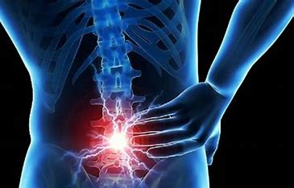

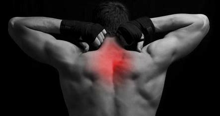

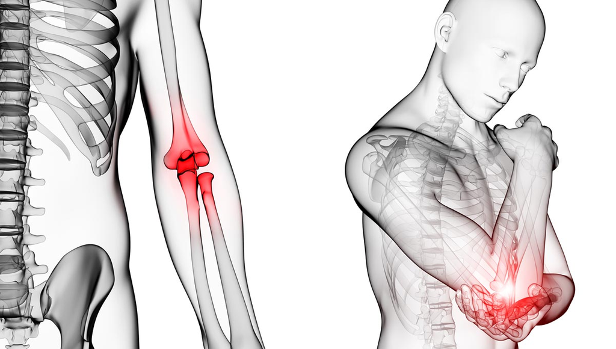

Función que determina la cantidad de personas que tienen una enfermedad segun el sexo y la enfermedad

```r
Cantidad1 <- df_cana_Esp$Obs[df_cana_Esp$Sexo == "Hombres" & df_cana_Esp$Nombre == "Problema óseo, articular o muscular que afecta principalmente a las caderas, las piernas o los pies"]

print(Cantidad1)
```

```
## [1] 26
```

```r
Cantidad2 <- df_cana_Esp$Obs[df_cana_Esp$Sexo == "Total" & df_cana_Esp$Nombre == "Problema óseo, articular o muscular que afecta principalmente al cuello, los hombros, los brazos o l"]

print (sum(Cantidad2))
```

```
## [1] 136
```